# Part_II_exploration

```python
#Installing the latest matplotlib version
!pip install matplotlib --upgrade
```

```python
#Importing relevant libraries
import pandas as pd
import numpy as np
import seaborn as sns
import matplotlib.pyplot as plt
%matplotlib inline
```

```python
#Loading the data
df_clean=pd.read_csv('/content/clean_loan_data.csv')
df_clean.head()
```

|  | ListingCreationDate | ListingNumber | ListingCategory | BorrowerState | IsBorrowerHomeowner | IncomeRange | IncomeVerifiable | DebtToIncomeRatio | StatedMonthlyIncome | Term | ProsperRating | EmploymentStatus | LoanStatus | LoanOriginalAmount | BorrowerAPR | Recommendations | LoanNumber | InvestmentFromFriendsCount | State |
| --- | --- | --- | --- | --- | --- | --- | --- | --- | --- | --- | --- | --- | --- | --- | --- | --- | --- | --- | --- |
| 0 | 2014-02-27 08:28:07.900 | 1209647 | Home Improvement | CO | False | $50,000-74,999 | True | 0.18 | 6125.000000 | 36 | A | Employed | Current | 10000 | 0.12016 | 0 | 134815 | 0 | Colorado |
| 1 | 2012-10-22 11:02:35.010 | 658116 | Motorcycle | GA | True | $25,000-49,999 | True | 0.15 | 2875.000000 | 36 | A | Employed | Current | 10000 | 0.12528 | 0 | 77296 | 0 | Georgia |
| 2 | 2013-09-14 18:38:39.097 | 909464 | Home Improvement | MN | True | $100,000+ | True | 0.26 | 9583.333333 | 36 | D | Employed | Current | 15000 | 0.24614 | 0 | 102670 | 0 | Minnesota |
| 3 | 2013-12-14 08:26:37.093 | 1074836 | Debt Consolidation | NM | True | $100,000+ | True | 0.36 | 8333.333333 | 60 | B | Employed | Current | 15000 | 0.15425 | 0 | 123257 | 0 | New Mexico |
| 4 | 2013-04-12 09:52:56.147 | 750899 | Debt Consolidation | KS | False | $25,000-49,999 | True | 0.27 | 2083.333333 | 36 | E | Employed | Current | 3000 | 0.31032 | 0 | 88353 | 0 | Kansas |

```python
# Toggle show/hide code cells in notebook environments
from IPython.display import HTML

HTML('''
code_show=true;
function code_toggle() {
 if (code_show){
 $('div.input').hide();
 } else {
 $('div.input').show();
 }
 code_show = !code_show
}
$( document ).ready(code_toggle);

''')
```

# **An Overview of Prosper**

- Prosper was founded in 2005 as the first peer-to-peer lending marketplace in the United States. Since then, Prosper has facilitated more than $23 billion in loans to more than 1,370,000 people.
- Through Prosper, people can invest in each other in a way that is financially and socially rewarding. Borrowers apply online for a fixed-rate, fixed-term loan between $2,000 and 40,000$.
- Individuals and institutions can invest in the loans and earn attractive returns. Prosper handles all loan servicing on behalf of the matched borrowers and investors.

At the end of this project we expect to understand the motivation towards loan acquisitions and what factors contribute to loan favorability and how they affect each other

# **The Dataset**

- The original data set contains 113,937 loans with 81 variables on each loan, including loan amount, borrower rate (or interest rate), current loan status, borrower income, and many others.
- After data wrangling and feature selection 76768 records and 19 variables remained for analysis.

# **Borrower Motivations**

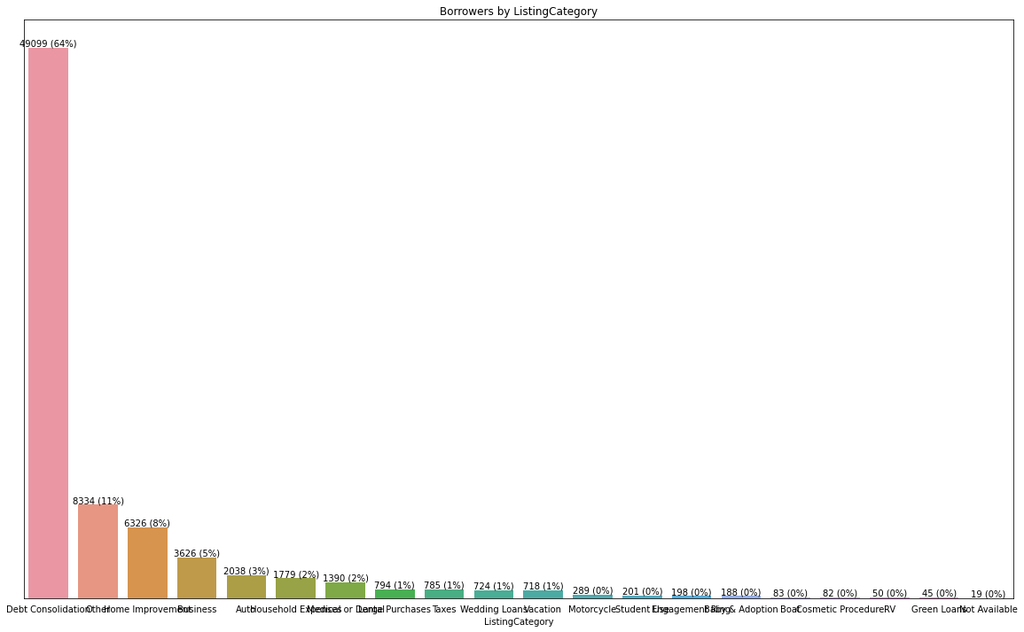

```python
#plotting the Listing Category
fig, ax = plt.subplots(figsize=(20,12))
ax=sns.countplot(data = df_clean, x= 'ListingCategory',order=df_clean['ListingCategory'].value_counts().index)


plt.xlabel('ListingCategory')
plt.title('Borrowers by ListingCategory')

ax.tick_params(bottom=False, left=False)
ax.grid(False)
ax.set(ylabel=None)
ax.set(yticklabels=[])
abs_values = df_clean['ListingCategory'].value_counts(ascending=False)
rel_values = df_clean['ListingCategory'].value_counts(ascending=False, normalize=True).values * 100
lbls = [f'{p[0]} ({p[1]:.0f}%)' for p in zip(abs_values, rel_values)]

ax.bar_label(container=ax.containers[0], labels=lbls);
```

- It's interesting to see more than 50% of borrowers ,take up loans to pay other debts,followed by other reasons,Home Improvement and Business reasons
- Borrowers also acquire loans for auto & household expenses,health,large purchases,taxes and wedding reasons

# **Loan Favorabilty**

- Prosper Ratings allow potential investors to easily consider a loan application's level of risk because the rating represents an estimated average annualized loss rate range to the investor.

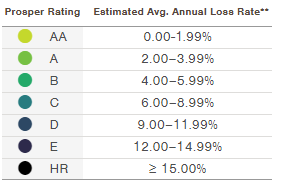

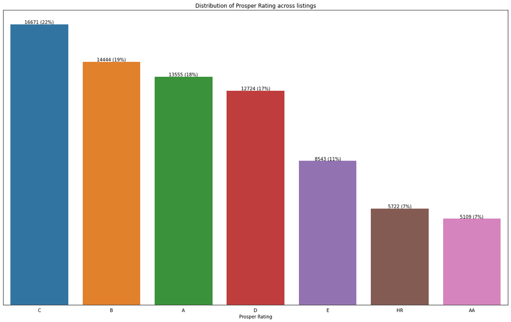

```python
#plotting the Prsoper rating
fig, ax = plt.subplots(figsize=(20,12))
ax=sns.countplot(data = df_clean, x = 'ProsperRating',orient="h",order=df_clean['ProsperRating'].value_counts().index)

plt.ylabel('Count')
plt.xlabel('Prosper Rating')
plt.title('Distribution of Prosper Rating across listings')
ax.tick_params(bottom=False, left=False)
ax.grid(False)
ax.set(ylabel=None)
ax.set(yticklabels=[])
abs_values = df_clean['ProsperRating'].value_counts(ascending=False)
rel_values = df_clean['ProsperRating'].value_counts(ascending=False, normalize=True).values * 100
lbls = [f'{p[0]} ({p[1]:.0f}%)' for p in zip(abs_values, rel_values)]

ax.bar_label(container=ax.containers[0], labels=lbls);
```

- Most listigs are medium gade with the least at extreme high risk & low risk

## **Prosper Rating vs Borrower APR**

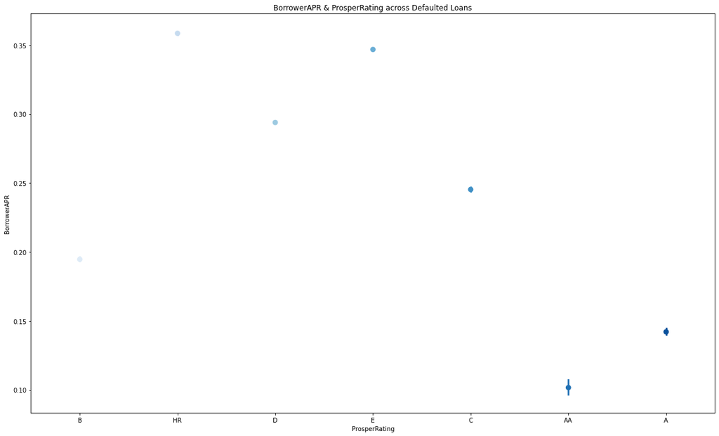

```python
#Subset data to get defaulted loans
defaulted=df_clean[df_clean['LoanStatus'].isin([ 'Past Due (1-15 days)', 'Defaulted', 'Chargedoff'])]
#plotting
plt.figure(figsize = [20,12])
sns.pointplot(data = defaulted, x = 'ProsperRating', y = 'BorrowerAPR',
                  palette = 'Blues', linestyles = '', dodge=True)
plt.title('BorrowerAPR & ProsperRating across Defaulted Loans')
plt.ylabel('BorrowerAPR');
```

- Using a subset of the data on defaulted loans,the higher the risk,the higher the Borrower APR which is true when we subset the defaulted loans.
- Since risk is high,we expect a higher interest charged on loans as a hedge for high risk volatility

## **Loan amount VS APR VS loan term**

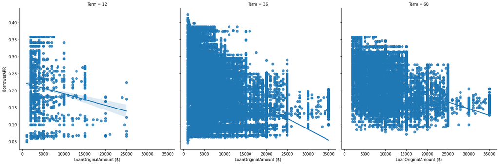

```python
# create faceted scatter plots on levels of the Term variable
ax = sns.FacetGrid(data = df_clean, col = 'Term', col_wrap = 3, height = 6)
ax.map(sns.regplot, 'LoanOriginalAmount', 'BorrowerAPR')
ax.set_xlabels('LoanOriginalAmount ($)')
ax.set_ylabels('BorrowerAPR');
```

- There's an inverse relationship between BorrowerAPR & Loan Amount as loan term increases
- The lower the borrowed amount ,the longer the term,the higher the interest rate

## **ProsperRating VS BorrowerAPR VS LoanAmount**

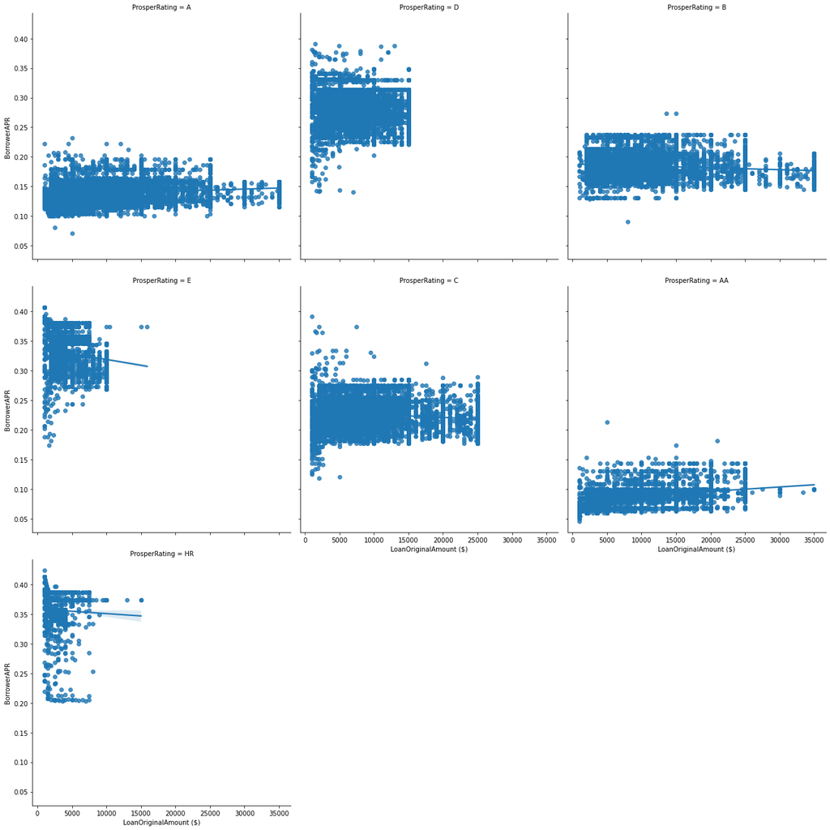

```python
# create faceted scatter plots on levels of the ProsperRating variable
ax = sns.FacetGrid(data = df_clean, col = 'ProsperRating', col_wrap = 3, height = 6)
ax.map(sns.regplot, 'LoanOriginalAmount', 'BorrowerAPR')
ax.set_xlabels('LoanOriginalAmount ($)')
ax.set_ylabels('BorrowerAPR');
```

The higher the risk,the lower the loan amount ,the higher the APR

# **Interesting Fun Fact**

- You would expect,Prosper rbeing a peer-to-peer lending platform,that most investors would invest loan amount for their friends but this is not the case.
- 99% of investment amount doesn't originate from their friends but from external parties

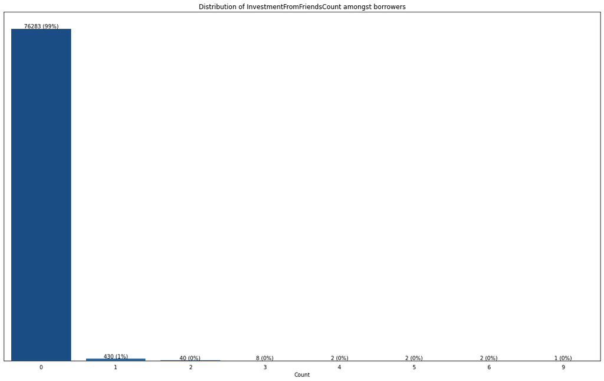

```python
#plotting the recommendations
fig, ax = plt.subplots(figsize=(20,12))
ax=sns.countplot(data = df_clean, x = 'InvestmentFromFriendsCount', palette = "Blues_r")

plt.ylabel('InvestmentFromFriendsCount')
plt.xlabel('Count')
plt.title('Distribution of InvestmentFromFriendsCount amongst borrowers')
ax.tick_params(bottom=False, left=False)
ax.set(ylabel=None)
ax.set(yticklabels=[])

abs_values = df_clean['InvestmentFromFriendsCount'].value_counts(ascending=False)
rel_values = df_clean['InvestmentFromFriendsCount'].value_counts(ascending=False, normalize=True).values * 100
lbls = [f'{p[0]} ({p[1]:.0f}%)' for p in zip(abs_values, rel_values)]

ax.bar_label(container=ax.containers[0], labels=lbls);
```